# ODE integration and sensitivity analysis

## Basic ODE integration

The `solve_ivp` function from SciPy is the most flexible and modern method for solving ODEs. It supports:

- Initial value problems (IVPs)
- Stiff and non-stiff problems
- Various integration methods: `RK45`, `RK23`, `Radau`, `BDF`, `LSODA`

It requires:

- A function that defines your differential equation.
- The time range over which you want to solve the ODE.
- The starting value of your system — a list or array of initial conditions.
- The integration method.
- A NumPy array of time points at which to store the solution. If not set, it only returns a few key points.

Let's try to solve the following differential equation with parameter $k=0.4$ and initial condition $y_{0} = 6$:

$$ \frac{dy}{dt} = -ky $$

```python
import numpy as np
from scipy.integrate import solve_ivp
import matplotlib.pyplot as plt

# Define the ODE
def model(t, y):    # Must always take two arguments: time t and state y. (Even if t isn't used.)
    k = 0.4
    return -k * y

# Time interval and initial condition
t_span = (0, 30)
y0 = [6]

# Define time points at which to evaluate the solution
t_eval = np.linspace(t_span[0], t_span[1], 100)

# Solve the ODE
sol = solve_ivp(model, t_span, y0, method='RK45', t_eval=t_eval)
```

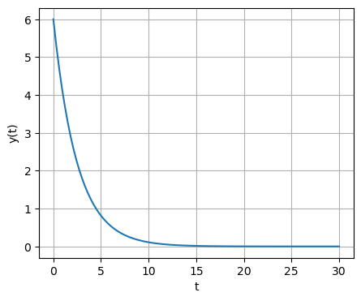

```python
# Plot
plt.figure(figsize=(5,4))
plt.plot(sol.t, sol.y[0])
plt.xlabel('t')
plt.ylabel('y(t)')
plt.grid(True)
plt.show()
```

An optional input of `solve_ivp` function is `args` that allows additional information to be passed into the model function.

The `args` input is a tuple sequence of values.

```python
def model(t, y, k):
    dydt = -k*y
    return dydt
```

```python
k = 0.1
sol1 = solve_ivp(model, t_span, y0, args=(k,), method='RK45', t_eval=t_eval)

k = 0.3
sol2 = solve_ivp(model, t_span, y0, args=(k,), method='RK45', t_eval=t_eval)

k = 0.6
sol3 = solve_ivp(model, t_span, y0, args=(k,), method='RK45', t_eval=t_eval)
```

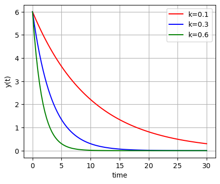

```python
plt.figure(figsize=(5,4))
plt.plot(sol1.t, sol1.y[0], 'r', label='k=0.1')
plt.plot(sol2.t, sol2.y[0], 'b', label='k=0.3')
plt.plot(sol3.t, sol3.y[0], 'g', label='k=0.6')
plt.xlabel('time')
plt.ylabel('y(t)')
plt.grid(True)
plt.legend(loc='best')
plt.show()
```

## Logistic growth

The logistic growth is a classic model used to describe how a population grows in an environment with **limited resources**.

$$ \frac{dy}{dt} = ry\left( 1 - \frac{y}{k} \right)$$

where $y(t)$ is the size of the population at time $t$, $r$ is the growth rate and $k$ is the carrying capacity, that is the number of people, other living organisms, or crops that a region can support without environmental degradation.

```python
def logistic(t, y, r, k):
    dydt = r*y*(1 - y/k)
    return dydt
```

```python
# initial condition
y0 = [10]

# time interval
t_span = (0, 120)

# time points at which to evaluate the solution
t_eval = np.linspace(t_span[0], t_span[1], 200)

# parameters
r = 0.1
k = 1500

# solve ODE
sol = solve_ivp(logistic, t_span, y0, args=(r, k), method='RK45', t_eval=t_eval)
```

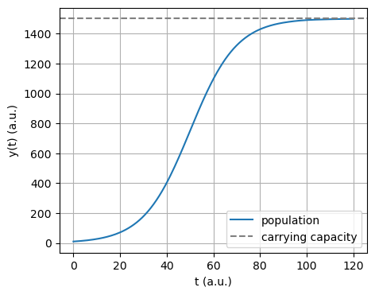

```python
# Plot
plt.figure(figsize=(5,4))
plt.plot(sol.t, sol.y[0], label='population')
plt.xlabel('t (a.u.)')
plt.ylabel('y(t) (a.u.)')
plt.grid(True)
plt.axhline(k, label='carrying capacity', color='gray', linestyle='--')
plt.legend(loc='best')
plt.show()
```

# Sensitivity analysis of ODE

Sensitivity analysis for ODEs helps you understand how sensitive the solution of an ODE is to changes in its parameters. This is useful in modeling and simulations, especially in contexts where parameters are often estimated or uncertain.

It is convenient to transform the result of the integration in a `pandas` dataframe.

This allows us to use it for better visualization through `seaborn`.

```python
import pandas as pd

def create_df(result, columns, **other_info):
    df = pd.DataFrame(result, columns=columns)
    for key, value in other_info.items():
        df[key] = value
    return df
```

```python
create_df(sol.y[0], ['population'], r=r, k=k, time=sol.t).head()
```

|  | population | r | k | time |
| --- | --- | --- | --- | --- |
| 0 | 10.000000 | 0.1 | 1500 | 0.000000 |
| 1 | 10.617168 | 0.1 | 1500 | 0.603015 |
| 2 | 11.272137 | 0.1 | 1500 | 1.206030 |
| 3 | 11.967188 | 0.1 | 1500 | 1.809045 |
| 4 | 12.704818 | 0.1 | 1500 | 2.412060 |

```python
# randomly generate 50 normally distributed values of r
rates = np.random.normal(r, 0.02, 50)

results = []
idx = 0
for ri in rates:
    sols = solve_ivp(logistic, t_span, y0, args=(ri, k), method='RK45', t_eval=t_eval)
    ys_df = create_df(sols.y[0], ['population'], r=ri, k=k, time=sols.t, simulation_run=idx)
    results.append(ys_df)
    idx = idx + 1
results = pd.concat(results, ignore_index=True)
```

```python
results
```

|  | population | r | k | time | simulation_run |
| --- | --- | --- | --- | --- | --- |
| 0 | 10.000000 | 0.102625 | 1500 | 0.000000 | 0 |
| 1 | 10.633870 | 0.102625 | 1500 | 0.603015 | 0 |
| 2 | 11.307614 | 0.102625 | 1500 | 1.206030 | 0 |
| 3 | 12.023702 | 0.102625 | 1500 | 1.809045 | 0 |
| 4 | 12.784842 | 0.102625 | 1500 | 2.412060 | 0 |
| ... | ... | ... | ... | ... | ... |
| 9995 | 1499.830245 | 0.123949 | 1500 | 117.587940 | 49 |
| 9996 | 1499.842255 | 0.123949 | 1500 | 118.190955 | 49 |
| 9997 | 1499.853413 | 0.123949 | 1500 | 118.793970 | 49 |
| 9998 | 1499.863818 | 0.123949 | 1500 | 119.396985 | 49 |
| 9999 | 1499.873564 | 0.123949 | 1500 | 120.000000 | 49 |

10000 rows × 5 columns

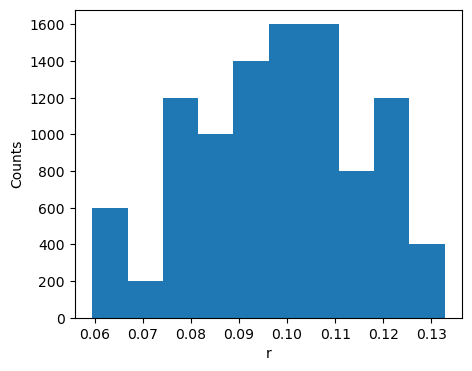

```python
plt.figure(figsize=(5,4))
plt.hist(results['r'], bins=10)
plt.ylabel('Counts')
plt.xlabel('r')
plt.show()
```

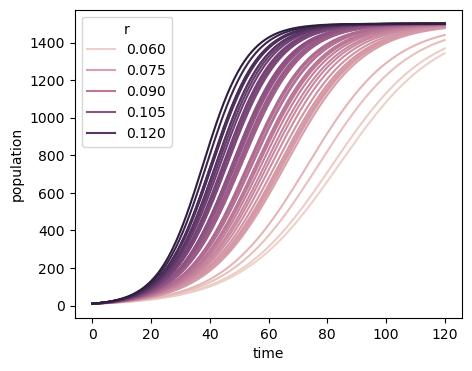

```python
import seaborn as sns

plt.figure(figsize=(5,4))
sns.lineplot(x="time", y="population", data=results, hue='r',
             estimator=None, units='simulation_run')
plt.show()
```

```python
# randomly generate 50 normally distributed values of k
capacities = np.random.normal(k, 100, 50)

results = []
idx = 0
for ci in capacities:
    sols = solve_ivp(logistic, t_span, y0, args=(r, ci), method='RK45', t_eval=t_eval)
    ys_df = create_df(sols.y[0], ['population'], r=r, k=ci, time=sols.t, simulation_run=idx)
    results.append(ys_df)
    idx = idx + 1
results = pd.concat(results, ignore_index=True)
```

```python
results
```

|  | population | r | k | time | simulation_run |
| --- | --- | --- | --- | --- | --- |
| 0 | 10.000000 | 0.1 | 1488.925980 | 0.000000 | 0 |
| 1 | 10.617135 | 0.1 | 1488.925980 | 0.603015 | 0 |
| 2 | 11.272066 | 0.1 | 1488.925980 | 1.206030 | 0 |
| 3 | 11.967071 | 0.1 | 1488.925980 | 1.809045 | 0 |
| 4 | 12.704646 | 0.1 | 1488.925980 | 2.412060 | 0 |
| ... | ... | ... | ... | ... | ... |
| 9995 | 1654.621309 | 0.1 | 1656.876566 | 117.587940 | 49 |
| 9996 | 1654.752925 | 0.1 | 1656.876566 | 118.190955 | 49 |
| 9997 | 1654.876859 | 0.1 | 1656.876566 | 118.793970 | 49 |
| 9998 | 1654.993598 | 0.1 | 1656.876566 | 119.396985 | 49 |
| 9999 | 1655.103609 | 0.1 | 1656.876566 | 120.000000 | 49 |

10000 rows × 5 columns

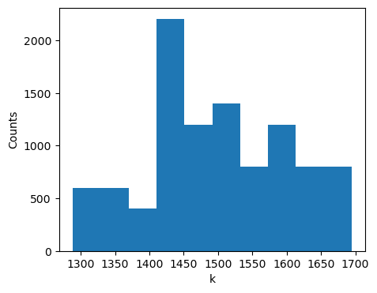

```python
plt.figure(figsize=(5,4))
plt.hist(results['k'], bins=10)
plt.ylabel('Counts')
plt.xlabel('k')
plt.show()
```

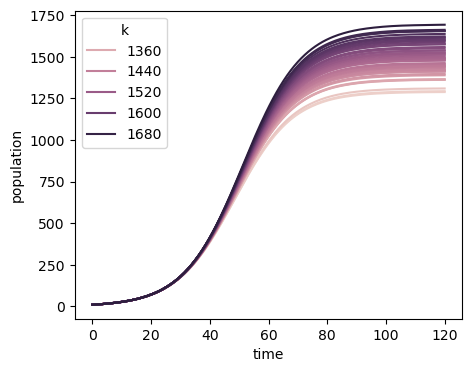

```python
plt.figure(figsize=(5,4))
sns.lineplot(x="time", y="population", data=results, hue='k',
             estimator=None, units='simulation_run')
plt.show()
```

## SIR model

The SIR model describes the evolution of a disease in a population.

$$ \begin{cases} \frac{dS}{dt} &= -\beta \frac{S I}{N} \\ \frac{dI}{dt} &= \beta \frac{S I}{N} - \gamma I \\ \frac{dR}{dt} &= \gamma I \end{cases} $$

Where:

- $S(t)$ = Susceptible individuals at time $t$
- $I(t)$ = Infected individuals at time $t$
- $R(t)$ = Recovered individuals at time $t$
- $\beta$ = Transmission rate
- $\gamma$ = Recovery rate
- $N$ = Total population (constant, $N = S + I + R$)

## Key Assumptions:

1. Homogeneous mixing
2. No birth or death
3. Immunity after recovery
4. No vaccination

We will represent all the populations using normalized concentrations.

```python
def sir(t, state, a, b):
    S, I, R = state
    dSdt = - a*S*I
    dIdt = + a*S*I - b*I
    dRdt = + b*I
    return dSdt, dIdt, dRdt
```

```python
# initial condition
state0 = (0.999, 0.001, 0.0)

# time interval
t_span = (0, 5)

# time points at which to evaluate the solution
t_eval = np.linspace(t_span[0], t_span[1], 100)

# parameters
a, b = 10, 1

# solve ODE
sol = solve_ivp(sir, t_span, state0, args=(a, b), method='RK45', t_eval=t_eval)
```

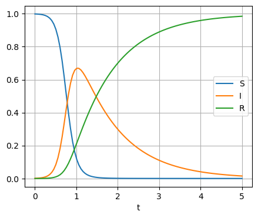

```python
plt.figure(figsize=(5,4))
plt.plot(sol.t, sol.y[0], label='S')
plt.plot(sol.t, sol.y[1], label='I')
plt.plot(sol.t, sol.y[2], label='R')
plt.grid(True)
plt.xlabel('t')
plt.legend(loc='best')
plt.show()
```

What happens if we change the value of one of the parameters?

```python
a_values = [2, 5, 10]  # Low, medium, and high transmission
colors = ['purple', 'orange', 'red']

# time interval
t_span = (0, 20)

# time points at which to evaluate the solution
t_eval = np.linspace(t_span[0], t_span[1], 100)
```

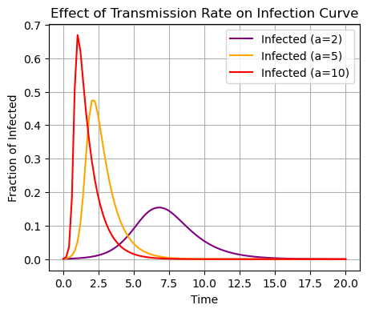

```python
plt.figure(figsize=(5,4))
for a, color in zip(a_values, colors):
    sol = solve_ivp(sir, t_span, state0, args=(a, b), t_eval=t_eval)
    plt.plot(t_eval, sol.y[1], label=f'Infected (a={a})', color=color)

plt.title('Effect of Transmission Rate on Infection Curve')
plt.xlabel('Time')
plt.ylabel('Fraction of Infected')
plt.legend()
plt.grid(True)
plt.show()
```

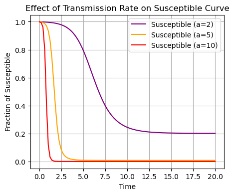

```python
plt.figure(figsize=(5,4))
for a, color in zip(a_values, colors):
    sol = solve_ivp(sir, t_span, state0, args=(a, b), t_eval=t_eval)
    plt.plot(t_eval, sol.y[0], label=f'Susceptible (a={a})', color=color)

plt.title('Effect of Transmission Rate on Susceptible Curve')
plt.xlabel('Time')
plt.ylabel('Fraction of Susceptible')
plt.legend()
plt.grid(True)
plt.show()
```

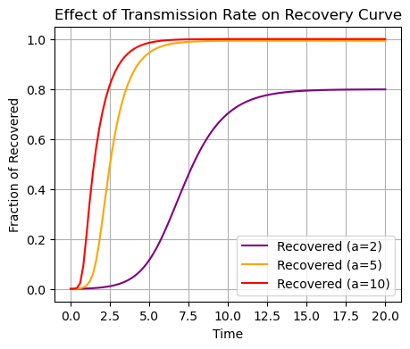

```python
plt.figure(figsize=(5,4))
for a, color in zip(a_values, colors):
    sol = solve_ivp(sir, t_span, state0, args=(a, b), t_eval=t_eval)
    plt.plot(t_eval, sol.y[2], label=f'Recovered (a={a})', color=color)

plt.title('Effect of Transmission Rate on Recovery Curve')
plt.xlabel('Time')
plt.ylabel('Fraction of Recovered')
plt.legend()
plt.grid(True)
plt.show()
```

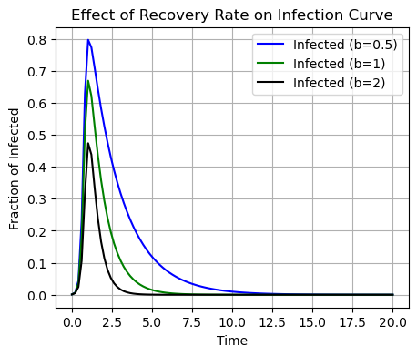

```python
b_values = [0.5, 1, 2]  # Slower, medium, faster recovery
colors = ['blue', 'green', 'black']

plt.figure(figsize=(5,4))
for b, color in zip(b_values, colors):
    sol = solve_ivp(sir, t_span, state0, args=(10, b), t_eval=t_eval)
    plt.plot(t_eval, sol.y[1], label=f'Infected (b={b})', color=color)

plt.title('Effect of Recovery Rate on Infection Curve')
plt.xlabel('Time')
plt.ylabel('Fraction of Infected')
plt.legend()
plt.grid(True)
plt.show()
```

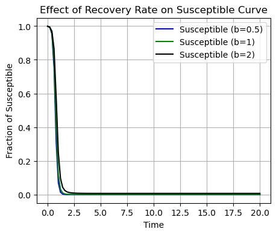

```python
plt.figure(figsize=(5,4))
for b, color in zip(b_values, colors):
    sol = solve_ivp(sir, t_span, state0, args=(10, b), t_eval=t_eval)
    plt.plot(t_eval, sol.y[0], label=f'Susceptible (b={b})', color=color)

plt.title('Effect of Recovery Rate on Susceptible Curve')
plt.xlabel('Time')
plt.ylabel('Fraction of Susceptible')
plt.legend()
plt.grid(True)
plt.show()
```

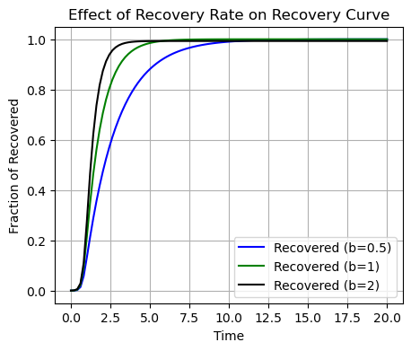

```python
plt.figure(figsize=(5,4))
for b, color in zip(b_values, colors):
    sol = solve_ivp(sir, t_span, state0, args=(10, b), t_eval=t_eval)
    plt.plot(t_eval, sol.y[2], label=f'Recovered (b={b})', color=color)

plt.title('Effect of Recovery Rate on Recovery Curve')
plt.xlabel('Time')
plt.ylabel('Fraction of Recovered')
plt.legend()
plt.grid(True)
plt.show()
```

```python
# randomly generate 50 normally distributed values of b around the value b
a, b = 10, 1
b_range = np.random.normal(b, 0.1, 50)

# time interval
t_span = (0, 5)

# time points at which to evaluate the solution
t_eval = np.linspace(t_span[0], t_span[1], 100)

results = []
cols = ['S', 'I', 'R']
idx = 0
for bi in b_range:
    sols = solve_ivp(sir, t_span, state0, args=(a, bi), method='RK45', t_eval=t_eval)
    res_i_df = create_df(np.transpose(sols.y), cols, a=a, b=bi, time=sols.t, simulation_run=idx, type='varying b')
    results.append(res_i_df)
    idx = idx + 1
results = pd.concat(results, ignore_index=True)
```

```python
results
```

|  | S | I | R | a | b | time | simulation_run | type |
| --- | --- | --- | --- | --- | --- | --- | --- | --- |
| 0 | 0.999000 | 0.001000 | 0.000000 | 10 | 0.972678 | 0.000000 | 0 | varying b |
| 1 | 0.998361 | 0.001577 | 0.000062 | 10 | 0.972678 | 0.050505 | 0 | varying b |
| 2 | 0.997355 | 0.002485 | 0.000160 | 10 | 0.972678 | 0.101010 | 0 | varying b |
| 3 | 0.995774 | 0.003912 | 0.000315 | 10 | 0.972678 | 0.151515 | 0 | varying b |
| 4 | 0.993285 | 0.006157 | 0.000558 | 10 | 0.972678 | 0.202020 | 0 | varying b |
| ... | ... | ... | ... | ... | ... | ... | ... | ... |
| 4995 | 0.000033 | 0.022876 | 0.977091 | 10 | 0.942648 | 4.797980 | 49 | varying b |
| 4996 | 0.000033 | 0.021813 | 0.978154 | 10 | 0.942648 | 4.848485 | 49 | varying b |
| 4997 | 0.000032 | 0.020799 | 0.979168 | 10 | 0.942648 | 4.898990 | 49 | varying b |
| 4998 | 0.000032 | 0.019833 | 0.980135 | 10 | 0.942648 | 4.949495 | 49 | varying b |
| 4999 | 0.000032 | 0.018911 | 0.981057 | 10 | 0.942648 | 5.000000 | 49 | varying b |

5000 rows × 8 columns

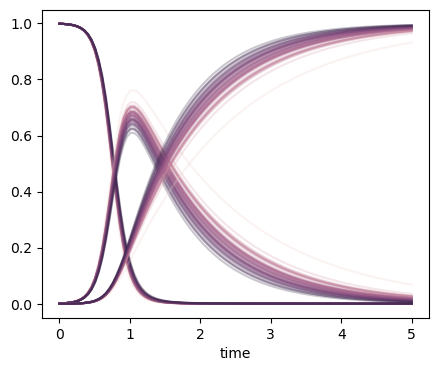

```python
args = dict(data=results, estimator=None, units='simulation_run', alpha=0.25, hue='b', legend=False)
plt.figure(figsize=(5,4))
sns.lineplot(x="time", y='S', **args).set(ylabel='')
sns.lineplot(x="time", y='I', **args).set(ylabel='')
sns.lineplot(x="time", y='R', **args).set(ylabel='')
plt.show()
```

We can observe what difference it makes if we let each parameter fluctuate one at the time, while fixing the others.

```python
# parameters
a, b = 10, 1

results = []
cols = ['S', 'I', 'R']

# randomly generate 50 normally distributed values of a around the value a=10
a_range = np.random.normal(a, a*0.1, 50)
idx = 0
for ai in a_range:
    sols = solve_ivp(sir, t_span, state0, args=(ai, b), method='RK45', t_eval=t_eval)
    res_i_df = create_df(np.transpose(sols.y), cols, a=ai, b=b, time=sols.t, simulation_run=idx, type='varying a')
    results.append(res_i_df)
    idx = idx + 1

# randomly generate 50 normally distributed values of b around the value b=1
b_range = np.random.normal(b, b*0.1, 50)
idx = 0
for bi in b_range:
    sols = solve_ivp(sir, t_span, state0, args=(a, bi), method='RK45', t_eval=t_eval)
    res_i_df = create_df(np.transpose(sols.y), cols, a=a, b=bi, time=sols.t, simulation_run=idx, type='varying b')
    results.append(res_i_df)
    idx = idx + 1

results = pd.concat(results, ignore_index=True)
```

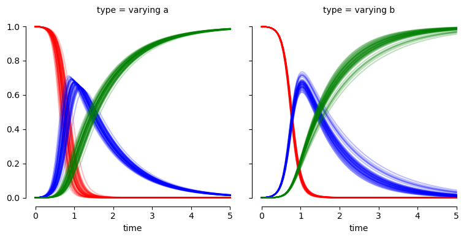

```python
fg = sns.FacetGrid(data=results, col='type', sharex=False, height=4, legend_out=False)
fg.map_dataframe(sns.lineplot, x="time", y='S', estimator=None, units='simulation_run', alpha=0.25, color='r')
fg.map_dataframe(sns.lineplot, x="time", y='I', estimator=None, units='simulation_run', alpha=0.25, color='b')
fg.map_dataframe(sns.lineplot, x="time", y='R', estimator=None, units='simulation_run', alpha=0.25, color='g')
fg.set(ylabel=None)
sns.despine(fg.fig, trim=True)
```

To have a better understanding, we could also use a subset of the phase space, to see how different variables change over time.

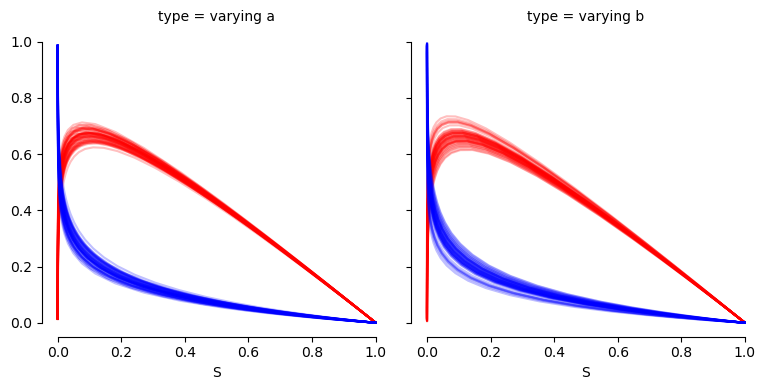

```python
fg = sns.FacetGrid(data=results, col='type', height=4)
fg.map_dataframe(sns.lineplot, x="S", y='I', estimator=None, units='simulation_run', alpha=0.25, color='r')
fg.map_dataframe(sns.lineplot, x="S", y='R', estimator=None, units='simulation_run', alpha=0.25, color='b')
fg.set(ylabel=None)
sns.despine(fg.fig, trim=True)
```

## Sampling with noise

Sampling with noise is a powerful approach for understanding how measurement noise or uncertainty in the data affects parameter estimation in models like ODEs.

This can be done by:

- Introducing noise to the model (e.g., by adding Gaussian noise).
- Fitting the model to these noisy data points.
- Observing the covariation between the parameters after fitting the model, or how the fitted parameters change when there is noise in the data.

Let's consider the logistic growth model.

```python
def logistic(t, y, r, k):
    dydt = r*y*(1 - y/k)
    return dydt
```

```python
# initial condition
y0 = [0.1]

# time interval
t_span = (0, 1)

# time points at which to evaluate the solution
t_eval = np.linspace(t_span[0], t_span[1], 100)

# parameters
r = 10
k = 1

# solve ODE
sol = solve_ivp(logistic, t_span, y0, args=(r, k), method='RK45', t_eval=t_eval)
```

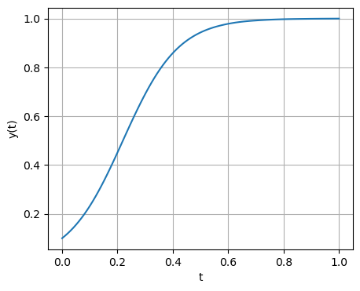

```python
plt.figure(figsize=(5,4))
plt.plot(sol.t, sol.y[0])
plt.xlabel('t')
plt.ylabel('y(t)')
plt.grid(True)
plt.show()
```

Let's add gaussian noise to our system.

To this end, we can use the `rvs` function from `scipy.stats`.

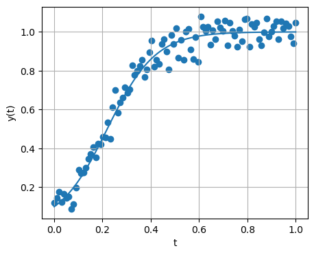

```python
import scipy.stats as st

y_hat_normal = st.norm.rvs(loc=sol.y[0], scale=0.05)

plt.figure(figsize=(5,4))
plt.plot(sol.t, sol.y[0])
plt.scatter(sol.t, y_hat_normal)
plt.xlabel('t')
plt.ylabel('y(t)')
plt.grid(True)
plt.show()
```

## Fitting procedure

To fit the model to these noisy data points, we will use the `curve_fit` function from `scipy.optimize`, that will give us an estimate of the parameters and their correlations.

To do this, it takes a function that, given the x values and a set of parameters, it gives the prediction.

First of all, let's see how it works in the simple case of a linear regression.

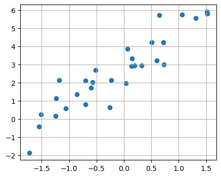

```python
from scipy.optimize import curve_fit

x = np.random.randn(30)
y = 2*x + 3 + np.random.randn(30)*0.8

plt.figure(figsize=(5,4))
plt.scatter(x, y)
plt.grid(True)
plt.show()
```

```python
def linear_fit(xdata, m, q):
    return m*xdata + q

p_avg, p_cov = curve_fit(linear_fit, x, y, p0=[1, 0])
```

```python
p_avg
```

```
array([1.97041754, 2.8566492 ])
```

```python
p_cov
```

```
array([[0.02515355, 0.00371359],
       [0.00371359, 0.0216504 ]])
```

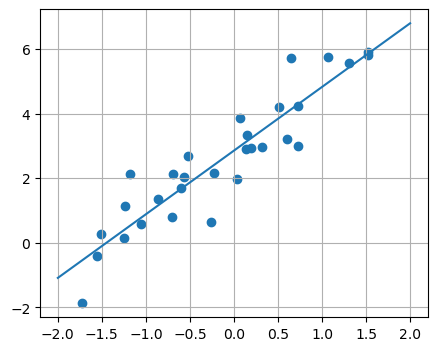

```python
x_values = np.linspace(-2, 2, 51)
y_hat = linear_fit(x_values, *p_avg)

plt.figure(figsize=(5,4))
plt.scatter(x, y)
plt.plot(x_values, y_hat)
plt.grid(True)
plt.show()
```

## How to visualize uncertainty?

- normal sampling
- 95% quantiles representation

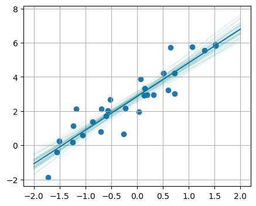

```python
p_seq = st.multivariate_normal.rvs(mean=p_avg, cov=p_cov, size=50)
x_base = np.linspace(-2, 2, 51)
y_hat = linear_fit(x_base, *p_avg)

plt.figure(figsize=(5,4))
plt.scatter(x, y)
plt.plot(x_base, y_hat)
plt.grid(True)

for params in p_seq:
    y_hat = linear_fit(x_base, *params)
    plt.plot(x_base, y_hat, color='teal', alpha=0.05)
```

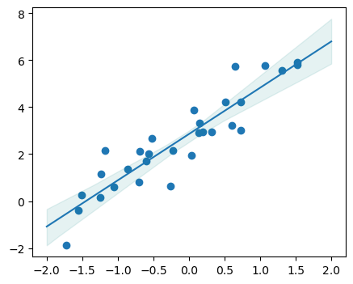

```python
from scipy.stats.mstats import mquantiles

p_seq = st.multivariate_normal.rvs(mean=p_avg, cov=p_cov, size=50)
x_base = np.linspace(-2, 2, 101)
y_hat = linear_fit(x_base, *p_avg)

plt.figure(figsize=(5,4))
plt.scatter(x, y)
plt.plot(x_base, y_hat)
y_hat = [linear_fit(x_base, *params) for params in p_seq]
y_hat = np.stack(y_hat)

p_low, p_top = mquantiles(y_hat, prob=[0.025, 0.975], axis=0)
plt.fill_between(x_base, p_low, p_top, alpha=0.1, color='teal')
plt.show()
```

```python
def logistic_fit(xdata, r, k):
    y0 = [0.1]
    sol = solve_ivp(logistic, t_span, y0, args=(r, k), method='RK45', t_eval=t_eval)
    return sol.y[0]

p_avg, p_cov = curve_fit(logistic_fit, t_eval, y_hat_normal, p0=[1, 0.1])
```

```python
p_avg
```

```
array([10.1414953 ,  1.00204976])
```

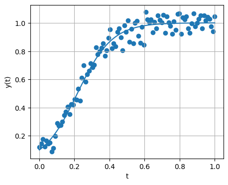

```python
y_fit = logistic_fit(t_eval, *p_avg)

plt.figure(figsize=(5,4))
plt.scatter(t_eval, y_hat_normal)
plt.plot(t_eval, y_fit)
plt.xlabel('t')
plt.ylabel('y(t)')
plt.grid(True)
plt.show()
```

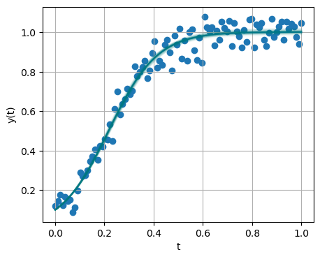

```python
p_seq = st.multivariate_normal.rvs(mean=p_avg, cov=p_cov, size=50)

plt.figure(figsize=(5,4))
plt.scatter(t_eval, y_hat_normal)
plt.plot(t_eval, y_fit)
plt.xlabel('t')
plt.ylabel('y(t)')
plt.grid(True)
for params in p_seq:
    y_hat_ = logistic_fit(t_eval, *params)
    plt.plot(t_eval, y_hat_, color='teal', alpha=0.05)
plt.show()
```

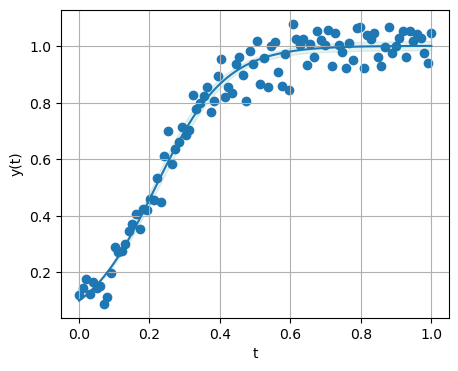

```python
p_seq = st.multivariate_normal.rvs(mean=p_avg, cov=p_cov, size=50)

plt.figure(figsize=(5,4))
plt.scatter(t_eval, y_hat_normal)
plt.plot(t_eval, y_fit)
plt.xlabel('t')
plt.ylabel('y(t)')
plt.grid(True)
y_hat_2 = [logistic_fit(t_eval, *params) for params in p_seq]
y_hat_2 = np.stack(y_hat_2)

p_low, p_top = mquantiles(y_hat_2, prob=[0.025, 0.975], axis=0)
plt.fill_between(t_eval, p_low, p_top, alpha=0.1, color='teal')
plt.show()
```

## Exercise

Consider the simple ODE shown as first example today:

$$ \frac{dy}{dt} = -ky $$

with parameter $k=0.4$ and initial condition $y_{0}=6$.

- Apply the two methods seen today to study the system.
- How would the results change if random samples were generated using the Van der Corput sequence?